# Diamonds

Ben Anderson and Trevor Andrus

# Import Necessary Packages from R

```r
library(corrplot)
library(ggplot2)
library(ggfortify)
library(car)
sz <- 22
```

# Data and Description

The purpose of this dataset is to determine what factors are most useful in predicting the price of a diamond. Several measurements are made when describing a diamond, and this study aims to see which of those measurements best determine the price.

This dataset has 53940 observations, but for ease of computation we took a random sample and reduced it to 300. The dataset was provided by a public posting on Kaggle and can be found at www.kaggle.com. We downloaded the CSV file on March 19, 2020. The data presents 9 factors which may potentially be useful in predicting diamond price. Each variable and its explanation is given below (note that ‘con’ represents a continuous variable and ‘cat’ represents a categorical variable) :

| Variable | Description |
| --- | --- |
| Carat (Con) | Measures the carat of diamond - ie. weight. |
| Cut (Cat) | Represents the type of diamond cut and has 5 levels: “Fair,”Good“,”Very Good“,”Ideal" and “Premium”. |
| Color (Cat) | Represents the color of the diamond and has 7 levels: (Best) “D”, “E”, “F”, “G”, “H”, “I”, and “J” (Worst). |
| Clarity (Cat) | Represents the clarity of the diamond and has 8 levels: (Worst) “I1”, “IF”, “SI1”, “SI2”, “VS1”, “VS2”, “VVS1” and “VVS2” (Best). |
| Depth (Con) | The measurement from the bottom tip of the diamond to the table (top) measured in millimeters but given as a percent |
| Table (Con) | Measures the facet of the diamond and is measured in millimeters, but given as a ratio at which the facet is widest. |
| X (Con) | Measures diamond length in mm |
| Y (Con) | Measures diamond width in mm |
| Z (Con) | Measures diamond depth in mm |

Given our knowledge of the data, we hypothesized that carat, cut, x, y, and z would all have a significant effect on the price of the diamond. Specifically, that as these measurements increase, we predicted that the price of the diamond would also increase accordingly.

In our analysis we checked the assumptions necessary to perform multiple linear regression. When we found that the raw data did not meet certain assumptions, we applied the necessary methods to clean the data and meet the assumptions. We found problems with homoscedasticity, the model fitting all observations, and multicollinearity. To fix the homoscedasticity assumption we performed a log transformation on price. To help the model fit all observations we ran models both with and without the influential points. We noted that the points did not significantly affect the model, and elected to leave them in. Finally, to fix multicollinearity we removed variables that showed a linear correlation between them. Once the assumptions were met, we performed multiple linear regression with price as the response, using the remaining variables for prediction.

We concluded our analysis by evaluating which of the variables were the most important in predicting the price of a diamond, and removed the variables that negatively affected the accuracy of our model. After our regression analysis, we determined that the model we created was very effective in predicting the price of a diamond given certain predictors.

# Step 1:

Importing data and taking a random sample to reduce computation time

```r
# setting seed to make the sample reproducible
set.seed(12345)

diamonds <- read.csv('diamonds.csv', header = TRUE)

# removing X identifier variable (X was an ID number for each diamond)
diamonds.s <- diamonds[sample(nrow(diamonds), 300), -1]
```

# Step 2:

Initial Exploratory Analysis

```r
# re-arranging columns
diamonds.s <- diamonds.s[,c(7, 1, 2, 3, 4, 5, 6, 8, 9, 10)]
head(diamonds.s)
```

```
##       price carat       cut color clarity depth table    x    y    z
## 10904  4886  1.01     Ideal     H     SI1  62.1    56 6.38 6.47 3.99
## 33373   827  0.41 Very Good     G     VS2  61.7    61 4.70 4.74 2.91
## 9986   4704  1.26     Ideal     I     SI2  59.6    57 7.04 7.01 4.19
## 75      554  0.30      Good     H     SI1  63.7    57 4.28 4.26 2.72
## 30311   726  0.34     Ideal     F     VS2  62.1    56 4.48 4.51 2.79
## 26378 15851  2.00 Very Good     F     SI1  63.3    56 8.00 7.93 5.04
```

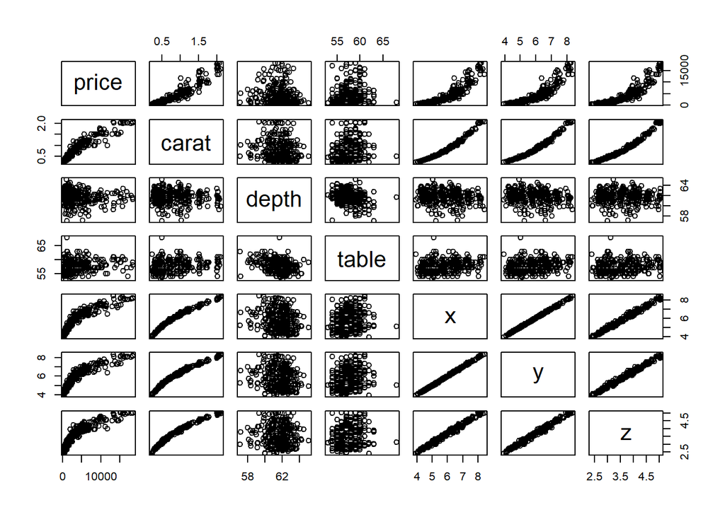

```r
# coercing categorical variables to factors
diamonds.s[, 3] <- as.factor(diamonds.s[, 3])
diamonds.s[, 4] <- as.factor(diamonds.s[, 4])
diamonds.s[, 5] <- as.factor(diamonds.s[, 5])

# checking scatter plot matrix with select variables
plot(diamonds.s[, c(1, 2, 6, 7, 8, 9, 10)])
```

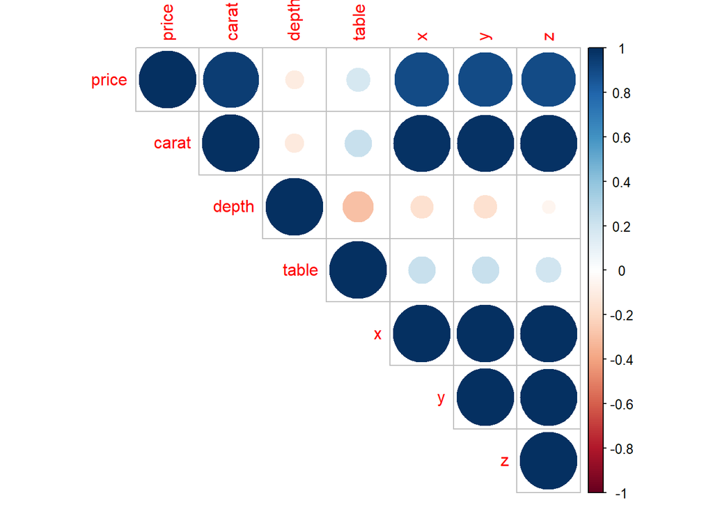

```r
# initial check for multicollinearity (removing categorical variables for plot)
corrplot(cor(diamonds.s[, c(1, 2, 6, 7, 8, 9, 10)]), type = "upper")
```

From our exploratory data analysis, we noticed several interesting things. Depth appeared to have a negative correlation with all other variables (including price), while the other variables had a positive correlation with price. There is very strong linear correlation between X, Y, Z and Carat. We found this intuitive because diamonds are cut proportionally.(X, Y, and Z must all be related to one another.) Knowing this, we address the multicollinearity problem later in our analysis.

# Step 3:

Linear Model

```r
# creating an initial linear model
diamonds.s.lm <- lm(price ~. , data = diamonds.s)
diamonds.s$residuals <- diamonds.s.lm$residuals
diamonds.s$fitted.values <- diamonds.s.lm$fitted.values

# summary of the linear model
summary(diamonds.s.lm)
```

```
##
## Call:
## lm(formula = price ~ ., data = diamonds.s)
##
## Residuals:
##     Min      1Q  Median      3Q     Max
## -2820.5  -473.7  -139.4   299.5  4674.5
##
## Coefficients:
##              Estimate Std. Error t value Pr(>|t|)
## (Intercept)  14672.90   16190.70   0.906 0.365591
## carat        15451.48     614.38  25.150  < 2e-16 ***
## cutGood       -315.65     583.28  -0.541 0.588836
## cutIdeal      -397.42     588.06  -0.676 0.499720
## cutPremium    -317.62     564.37  -0.563 0.574031
## cutVery Good  -631.91     570.33  -1.108 0.268845
## colorE        -153.04     184.61  -0.829 0.407822
## colorF        -372.03     186.80  -1.992 0.047398 *
## colorG        -578.61     185.62  -3.117 0.002019 **
## colorH       -1015.49     194.40  -5.224 3.46e-07 ***
## colorI       -1482.83     213.41  -6.948 2.66e-11 ***
## colorJ       -3222.87     325.16  -9.912  < 2e-16 ***
## clarityIF     4481.86     533.52   8.401 2.37e-15 ***
## claritySI1    3204.45     471.75   6.793 6.75e-11 ***
## claritySI2    2282.02     475.90   4.795 2.66e-06 ***
## clarityVS1    3876.49     486.84   7.963 4.42e-14 ***
## clarityVS2    3681.18     474.21   7.763 1.63e-13 ***
## clarityVVS1   4518.31     518.65   8.712 2.81e-16 ***
## clarityVVS2   4043.45     500.81   8.074 2.12e-14 ***
## depth         -119.22     252.64  -0.472 0.637380
## table          -50.50      31.67  -1.594 0.111975
## x            -6453.22    1713.10  -3.767 0.000202 ***
## y             2897.38    1841.70   1.573 0.116815
## z             1487.76    4206.13   0.354 0.723824
## ---
## Signif. codes:  0 '***' 0.001 '**' 0.01 '*' 0.05 '.' 0.1 ' ' 1
##
## Residual standard error: 859.7 on 276 degrees of freedom
## Multiple R-squared:  0.9593, Adjusted R-squared:  0.9559
## F-statistic: 282.7 on 23 and 276 DF,  p-value: < 2.2e-16
```

# Step 4: Checking assumptions for linear regression

## Linearity

#### Residuals v Predictor Plots

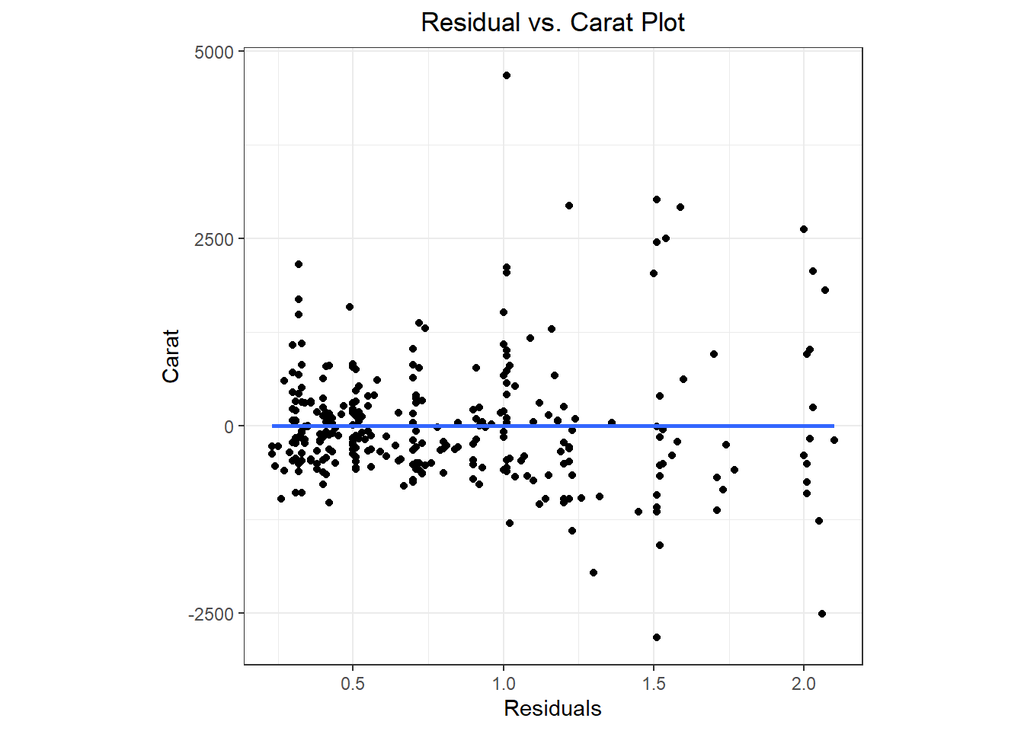

```r
# carat
ggplot(data = diamonds.s, mapping = aes(x = carat, y = residuals)) +
  geom_point() +
  geom_point() +
  theme_bw() +
  xlab("Residuals") +
  ylab("Carat") +
  ggtitle("Residual vs. Carat Plot") +
  theme(aspect.ratio = 1) +
  theme(plot.title = element_text(hjust = 0.5)) +
  geom_smooth(method = "lm", se = FALSE)
```

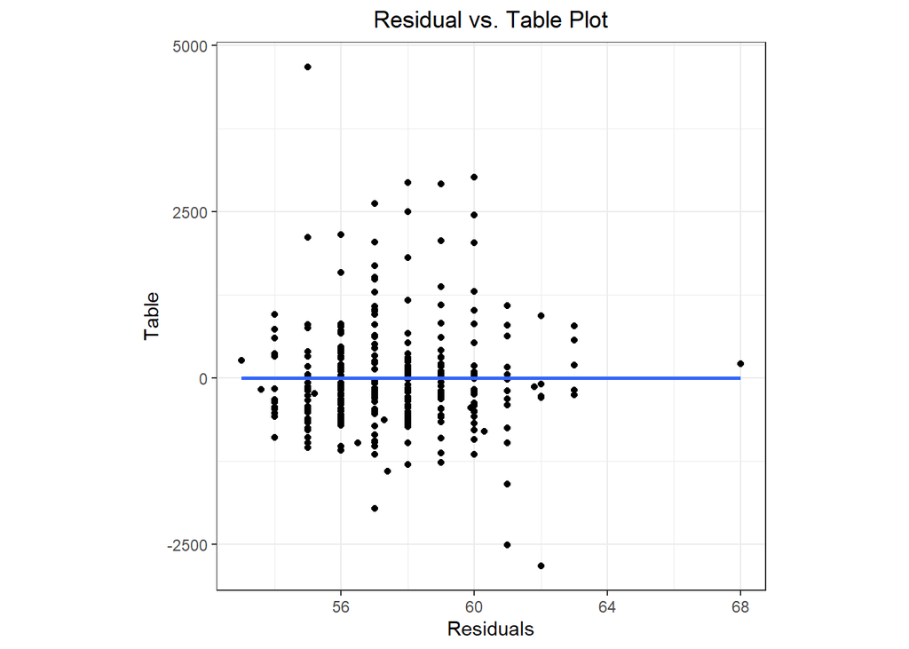

```r
# table
ggplot(data = diamonds.s, mapping = aes(x = table, y = residuals)) +
  geom_point() +
  geom_point() +
  theme_bw() +
  xlab("Residuals") +
  ylab("Table") +
  ggtitle("Residual vs. Table Plot") +
  theme(aspect.ratio = 1) +
  theme(plot.title = element_text(hjust = 0.5)) +
  geom_smooth(method = "lm", se = FALSE)
```

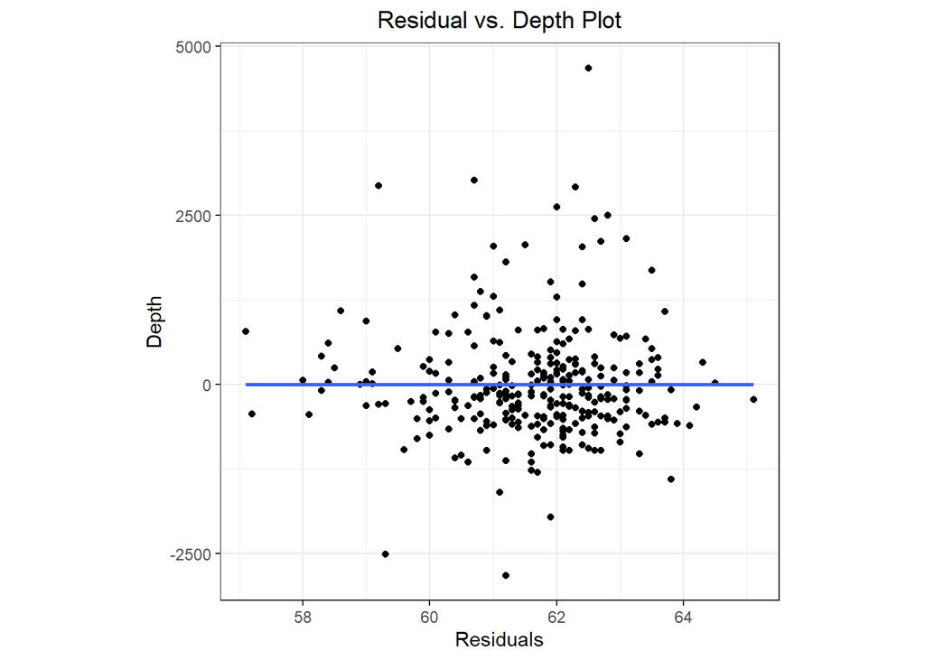

```r
# depth
ggplot(data = diamonds.s, mapping = aes(x = depth, y = residuals)) +
  geom_point() +
  geom_point() +
  theme_bw() +
  xlab("Residuals") +
  ylab("Depth") +
  ggtitle("Residual vs. Depth Plot") +
  theme(aspect.ratio = 1) +
  theme(plot.title = element_text(hjust = 0.5)) +
  geom_smooth(method = "lm", se = FALSE)
```

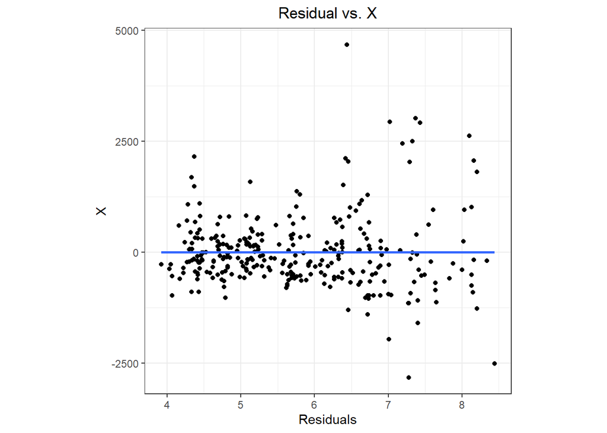

```r
# x
ggplot(data = diamonds.s, mapping = aes(x = x, y = residuals)) +
  geom_point() +
  geom_point() +
  theme_bw() +
  xlab("Residuals") +
  ylab("X") +
  ggtitle("Residual vs. X") +
  theme(aspect.ratio = 1) +
  theme(plot.title = element_text(hjust = 0.5)) +
  geom_smooth(method = "lm", se = FALSE)
```

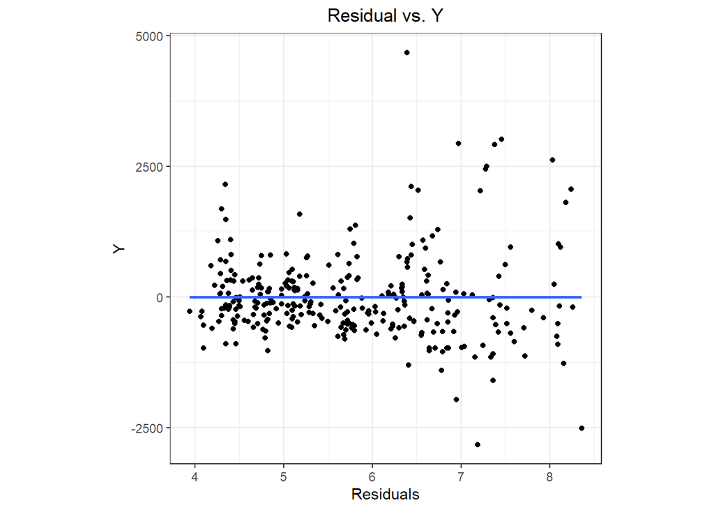

```r
# y
ggplot(data = diamonds.s, mapping = aes(x = y, y = residuals)) +
  geom_point() +
  geom_point() +
  theme_bw() +
  xlab("Residuals") +
  ylab("Y") +
  ggtitle("Residual vs. Y") +
  theme(aspect.ratio = 1) +
  theme(plot.title = element_text(hjust = 0.5)) +
  geom_smooth(method = "lm", se = FALSE)
```

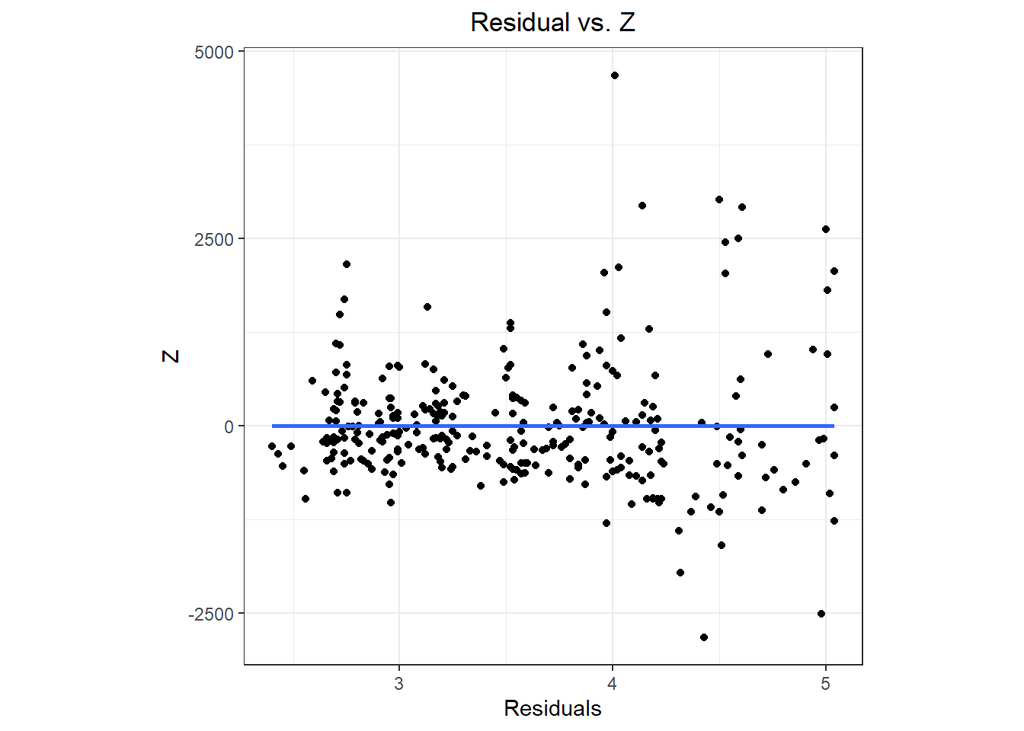

```r
# z
ggplot(data = diamonds.s, mapping = aes(x = z, y = residuals)) +
  geom_point() +
  geom_point() +
  theme_bw() +
  xlab("Residuals") +
  ylab("Z") +
  ggtitle("Residual vs. Z") +
  theme(aspect.ratio = 1) +
  theme(plot.title = element_text(hjust = 0.5)) +
  geom_smooth(method = "lm", se = FALSE)
```

#### AV plots

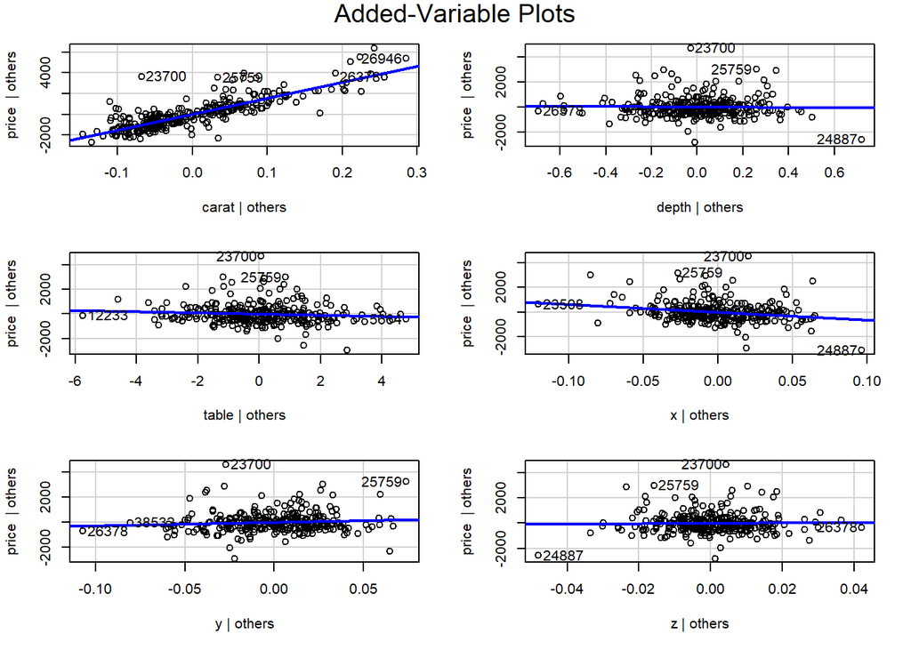

```r
avPlots(diamonds.s.lm, terms = ~ carat + depth + table + x + y + z)
```

#### Residual v Fitted Values

```r
ggplot(data = diamonds.s, mapping = aes(x = fitted.values, y = residuals)) +
  geom_point() +
  theme_bw() +
  theme(aspect.ratio = 1) +
  theme(plot.title = element_text(hjust = 0.5)) +
  xlab("Residuals") +
  ylab("Fitted Values") +
  ggtitle("Residuals vs Fitted Value Plot") +
  geom_smooth(method = 'lm', se = FALSE)
```

[output not shown]

## Independence

We assume the assumption of independent residuals to be met because we took a random sample from a larger data set.

## Residuals are Normally Distributed and Centered at 0

#### Residual Boxplot

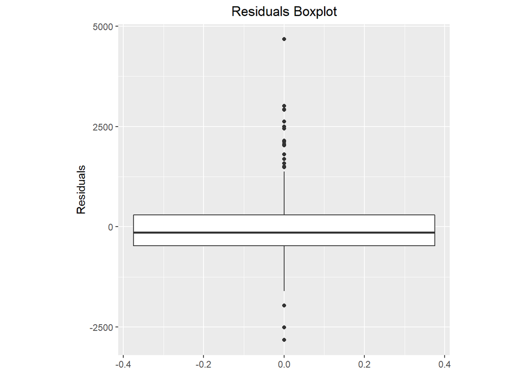

```r
ggplot(data = diamonds.s, mapping = aes(y = residuals)) +
  geom_boxplot() +
  ylab("Residuals") +
  ggtitle("Residuals Boxplot") +
  theme(aspect.ratio = 1) +
  theme(plot.title = element_text(hjust = 0.5))
```

#### Histogram of Residuals

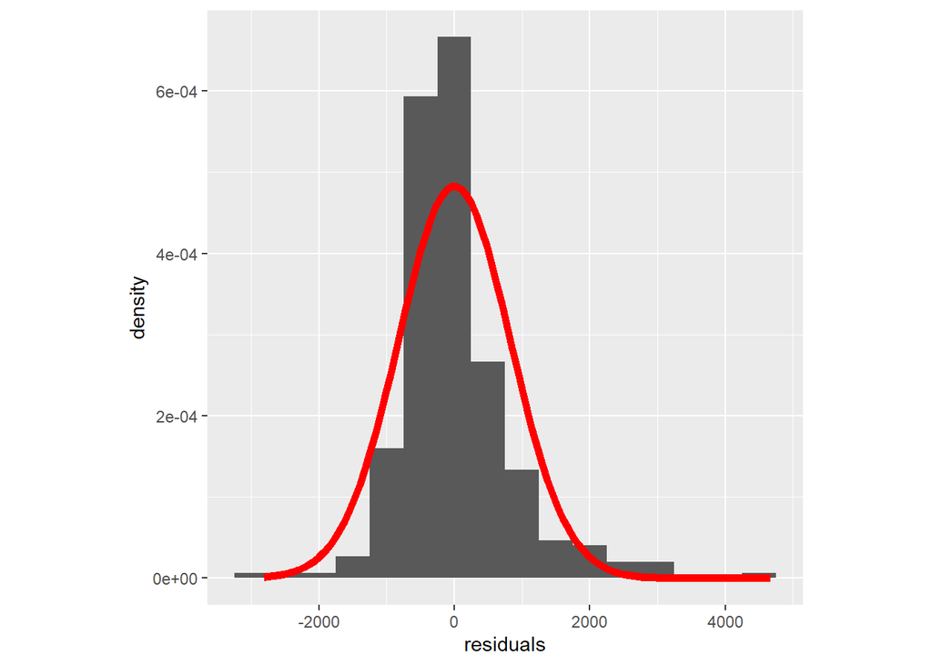

```r
ggplot(data = diamonds.s, mapping = aes(x = residuals)) +
  geom_histogram(mapping = aes(y = ..density..), binwidth = 500) +
  stat_function(fun = dnorm, color = "red", size = 2,
                args = list(mean = mean(diamonds.s$residuals),
                            sd = sd(diamonds.s$residuals))) +
  theme(aspect.ratio = 1)
```

#### Shapiro-Wilk Test for Normality

```r
shapiro.test(diamonds.s.lm$residuals)
```

```
##
##  Shapiro-Wilk normality test
##
## data:  diamonds.s.lm$residuals
## W = 0.89192, p-value = 9.006e-14
```

Looking at both the boxplot of the residuals and the histogram, it seemed that the residuals are right skewed and may not meet the normality assumption. There did seem to be some outliers (which may suggest why we failed the Shapiro-Wilk test for normality). The Shairpo-Wilk test also indicates that normality may not be met.

## Homoscedasticity (equal variance)

#### Residuals v Fitted values plot

```r
ggplot(data = diamonds.s, mapping = aes(x = fitted.values, y = residuals)) +
  geom_point() +
  theme_bw() +
  theme(aspect.ratio = 1) +
  theme(plot.title = element_text(hjust = 0.5)) +
  xlab("Residuals") +
  ylab("Fitted Values") +
  ggtitle("Residuals vs Fitted Value Plot") +
  geom_smooth(method = 'lm', se = FALSE)
```

[output not shown]

#### Boxplots for Categorical Variables

```r
# #Cut
# ggplot(data = diamonds.s, mapping = aes(x = cut, y = price)) +
#   geom_boxplot() +
#   theme_bw() +
#   xlab("Cut") +
#   ylab("Price") +
#   ggtitle("Cut Boxplot") +
#   theme(aspect.ratio = 1) +
#   theme(plot.title = element_text(hjust = 0.5))
#
# #Color
# ggplot(data = diamonds.s, mapping = aes(x = clarity, y = price)) +
#   geom_boxplot() +
#   theme_bw() +
#   xlab("Clarity") +
#   ylab("Price") +
#   ggtitle("Clarity Boxplot") +
#   theme(aspect.ratio = 1) +
#   theme(plot.title = element_text(hjust = 0.5))
#
# #Clarity
# ggplot(data = diamonds.s, mapping = aes(x = color, y = price)) +
#   geom_boxplot() +
#   theme_bw() +
#   xlab("Color") +
#   ylab("Price") +
#   ggtitle("Color Boxplot") +
#   theme(aspect.ratio = 1) +
#   theme(plot.title = element_text(hjust = 0.5))
```

## Model Describes all Points (No Outliers)

#### DFFITS

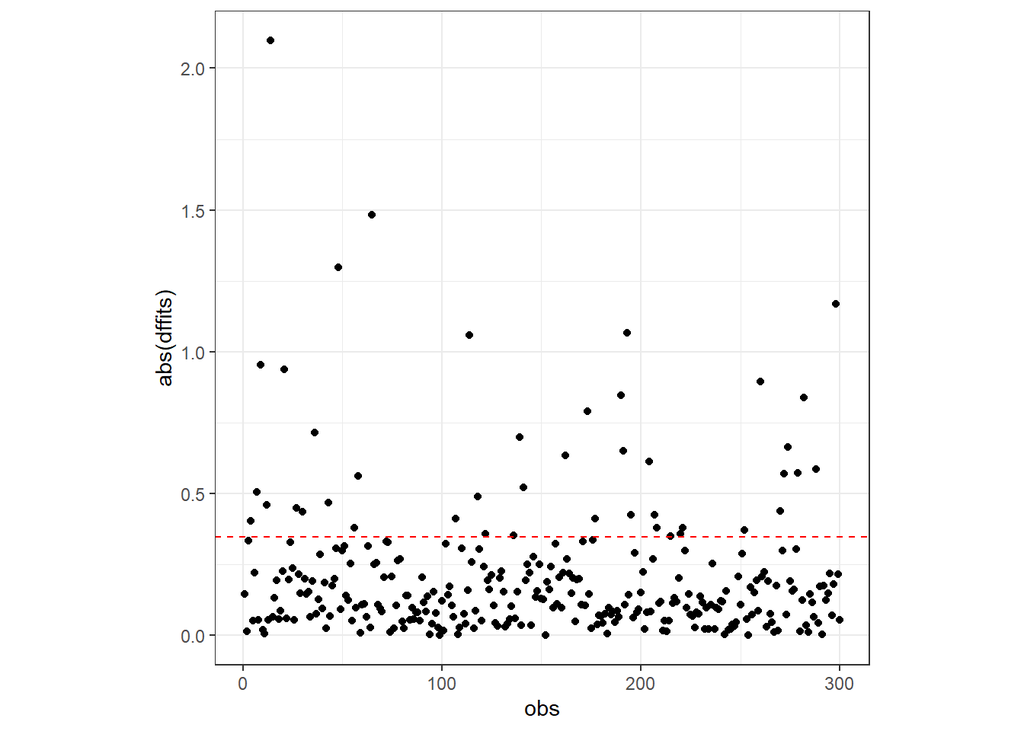

```r
diamonds.s.dffits <- data.frame("dffits" = dffits(diamonds.s.lm))
diamonds.s.dffits$obs <- 1:length(diamonds.s$price)

ggplot(data = diamonds.s.dffits) +
  geom_point(mapping = aes(x = obs, y = abs(dffits))) +
  geom_hline(mapping = aes(yintercept = 2 * sqrt(9 / length(obs))),
             color = "red", linetype = "dashed") +
  theme_bw() +
  theme(aspect.ratio = 1)
```

```r
#diamonds.s.dffits[abs(diamonds.s.dffits$dffits) > 2 * sqrt(9 / 300), ]
```

#### DFBETAS

```r
# ## Carat
# diamonds.s.dfbetas <- as.data.frame(dfbetas(diamonds.s.lm))
# diamonds.s.dfbetas$obs <- 1:length(diamonds.s$price)
#
# ggplot(data = diamonds.s.dfbetas) +
#   geom_point(mapping = aes(x = obs, y = abs(carat))) +
#   geom_hline(mapping = aes(yintercept = 1),
#              color = "red", linetype = "dashed") +  # for n <= 30
#   geom_hline(mapping = aes(yintercept = 2 / sqrt(length(obs))),
#              color = "red", linetype = "dashed") +  # for n > 30
#   theme_bw() +
#   theme(aspect.ratio = 1)
#
# carat.extreme.dfbetas <- diamonds.s.dfbetas[abs(diamonds.s.dfbetas$carat) > 1, ]
# carat.extreme.dfbetas[order(carat.extreme.dfbetas$carat), ]
#
# ##Depth
# diamonds.s.dfbetas <- as.data.frame(dfbetas(diamonds.s.lm))
# diamonds.s.dfbetas$obs <- 1:length(diamonds.s$price)
#
# ggplot(data = diamonds.s.dfbetas) +
#   geom_point(mapping = aes(x = obs, y = abs(depth))) +
#   geom_hline(mapping = aes(yintercept = 1),
#              color = "red", linetype = "dashed") +  # for n <= 30
#   geom_hline(mapping = aes(yintercept = 2 / sqrt(length(obs))),
#              color = "red", linetype = "dashed") +  # for n > 30
#   theme_bw() +
#   theme(aspect.ratio = 1)
#
# depth.extreme.dfbetas <- diamonds.s.dfbetas[abs(diamonds.s.dfbetas$depth) > 1, ]
# depth.extreme.dfbetas[order(depth.extreme.dfbetas$depth), ]
#
#
# ## Table
# diamonds.s.dfbetas <- as.data.frame(dfbetas(diamonds.s.lm))
# diamonds.s.dfbetas$obs <- 1:length(diamonds.s$price)
#
# ggplot(data = diamonds.s.dfbetas) +
#   geom_point(mapping = aes(x = obs, y = abs(table))) +
#   geom_hline(mapping = aes(yintercept = 1),
#              color = "red", linetype = "dashed") +  # for n <= 30
#   geom_hline(mapping = aes(yintercept = 2 / sqrt(length(obs))),
#              color = "red", linetype = "dashed") +  # for n > 30
#   theme_bw() +
#   theme(aspect.ratio = 1)
#
# table.extreme.dfbetas <- diamonds.s.dfbetas[abs(diamonds.s.dfbetas$table) > 1, ]
# table.extreme.dfbetas[order(table.extreme.dfbetas$table), ]
#
# ## X
# diamonds.s.dfbetas <- as.data.frame(dfbetas(diamonds.s.lm))
# diamonds.s.dfbetas$obs <- 1:length(diamonds.s$price)
#
# ggplot(data = diamonds.s.dfbetas) +
#   geom_point(mapping = aes(x = obs, y = abs(x))) +
#   geom_hline(mapping = aes(yintercept = 1),
#              color = "red", linetype = "dashed") +  # for n <= 30
#   geom_hline(mapping = aes(yintercept = 2 / sqrt(length(obs))),
#              color = "red", linetype = "dashed") +  # for n > 30
#   theme_bw() +
#   theme(aspect.ratio = 1)
#
# x.extreme.dfbetas <- diamonds.s.dfbetas[abs(diamonds.s.dfbetas$x) > 1, ]
# x.extreme.dfbetas[order(x.extreme.dfbetas$x), ]
#
# ## Y
# diamonds.s.dfbetas <- as.data.frame(dfbetas(diamonds.s.lm))
# diamonds.s.dfbetas$obs <- 1:length(diamonds.s$price)
#
# ggplot(data = diamonds.s.dfbetas) +
#   geom_point(mapping = aes(x = obs, y = abs(y))) +
#   geom_hline(mapping = aes(yintercept = 1),
#              color = "red", linetype = "dashed") +  # for n <= 30
#   geom_hline(mapping = aes(yintercept = 2 / sqrt(length(obs))),
#              color = "red", linetype = "dashed") +  # for n > 30
#   theme_bw() +
#   theme(aspect.ratio = 1)
#
# y.extreme.dfbetas <- diamonds.s.dfbetas[abs(diamonds.s.dfbetas$y) > 1, ]
# y.extreme.dfbetas[order(y.extreme.dfbetas$y), ]
#
# ## Z
# diamonds.s.dfbetas <- as.data.frame(dfbetas(diamonds.s.lm))
# diamonds.s.dfbetas$obs <- 1:length(diamonds.s$price)
#
# ggplot(data = diamonds.s.dfbetas) +
#   geom_point(mapping = aes(x = obs, y = abs(z))) +
#   geom_hline(mapping = aes(yintercept = 1),
#              color = "red", linetype = "dashed") +  # for n <= 30
#   geom_hline(mapping = aes(yintercept = 2 / sqrt(length(obs))),
#              color = "red", linetype = "dashed") +  # for n > 30
#   theme_bw() +
#   theme(aspect.ratio = 1)
#
# #identifies any observations with a DFBETA greater
# # than one (as seen on the plot)
# z.extreme.dfbetas <- diamonds.s.dfbetas[abs(diamonds.s.dfbetas$z) > 1, ]
# z.extreme.dfbetas[order(z.extreme.dfbetas$z), ]
```

## No Multicollinearity

##### Correlation matrix

```r
#corrplot(cor(diamonds.s[, c(1, 2, 6, 7, 8, 9, 10)]), type = "upper")
```

#### VIF values

```r
vif(diamonds.s.lm)
```

```
##                GVIF Df GVIF^(1/(2*Df))
## carat     34.075503  1        5.837423
## cut        2.936517  4        1.144140
## color      1.698535  6        1.045136
## clarity    2.265528  7        1.060155
## depth     43.333817  1        6.582843
## table      1.897128  1        1.377363
## x       1488.410726  1       38.579926
## y       1690.026087  1       41.109927
## z       3293.296083  1       57.387247
```

```r
mean(vif(diamonds.s.lm)[,1])
```

```
## [1] 728.66
```

# Step 5: Correcting failed assumptions

#### Dealing with Homoscedasity

#### Box-Cox Test

```r
bc <- boxCox(diamonds.s$price ~ diamonds.s$carat + diamonds.s$cut + diamonds.s$color + diamonds.s$clarity + diamonds.s$depth + diamonds.s$table + diamonds.s$x + diamonds.s$y + diamonds.s$z)
```

[figure not shown]

After viewing the Box-Cox test, it was apparent that we needed to do a log transform of our response variable. (a lambda value of 0 indicates a log transform). We proceeded to make a new model with the log of price as the response, and again looked at the residual v fitted plot to see if our transformation improved homoscedasticity.

## Transforming Price and Creating New Linear Model

```r
diamonds.s.transform <- diamonds.s
diamonds.s.transform[,1] <- log(diamonds.s.transform[,1])

diamonds.transform.lm <- lm(price ~. , data = diamonds.s.transform)
diamonds.s.transform$residuals <- diamonds.transform.lm$residuals
diamonds.s.transform$fitted.values <- diamonds.transform.lm$fitted.values
```

## Linearity

#### Residuals v Predictor Plots

```r
# # carat
# ggplot(data = diamonds.s.transform, mapping = aes(x = carat, y = residuals)) +
#   geom_point() +
#   geom_point() +
#   theme_bw() +
#   xlab("Residuals") +
#   ylab("Carat") +
#   ggtitle("Residual vs. Carat Plot") +
#   theme(aspect.ratio = 1) +
#   theme(plot.title = element_text(hjust = 0.5)) +
#   geom_smooth(method = "lm", se = FALSE)
#
# # table
# ggplot(data = diamonds.s.transform, mapping = aes(x = table, y = residuals)) +
#   geom_point() +
#   geom_point() +
#   theme_bw() +
#   xlab("Residuals") +
#   ylab("Table") +
#   ggtitle("Residual vs. Table Plot") +
#   theme(aspect.ratio = 1) +
#   theme(plot.title = element_text(hjust = 0.5)) +
#   geom_smooth(method = "lm", se = FALSE)
#
# # depth
# ggplot(data = diamonds.s.transform, mapping = aes(x = depth, y = residuals)) +
#   geom_point() +
#   geom_point() +
#   theme_bw() +
#   xlab("Residuals") +
#   ylab("Depth") +
#   ggtitle("Residual vs. Depth Plot") +
#   theme(aspect.ratio = 1) +
#   theme(plot.title = element_text(hjust = 0.5)) +
#   geom_smooth(method = "lm", se = FALSE)
#
# # x
# ggplot(data = diamonds.s.transform, mapping = aes(x = x, y = residuals)) +
#   geom_point() +
#   geom_point() +
#   theme_bw() +
#   xlab("Residuals") +
#   ylab("X") +
#   ggtitle("Residual vs. X") +
#   theme(aspect.ratio = 1) +
#   theme(plot.title = element_text(hjust = 0.5)) +
#   geom_smooth(method = "lm", se = FALSE)
#
# # y
# ggplot(data = diamonds.s.transform, mapping = aes(x = y, y = residuals)) +
#   geom_point() +
#   geom_point() +
#   theme_bw() +
#   xlab("Residuals") +
#   ylab("Y") +
#   ggtitle("Residual vs. Y") +
#   theme(aspect.ratio = 1) +
#   theme(plot.title = element_text(hjust = 0.5)) +
#   geom_smooth(method = "lm", se = FALSE)
#
# # z
# ggplot(data = diamonds.s.transform, mapping = aes(x = z, y = residuals)) +
#   geom_point() +
#   geom_point() +
#   theme_bw() +
#   xlab("Residuals") +
#   ylab("Z") +
#   ggtitle("Residual vs. Z") +
#   theme(aspect.ratio = 1) +
#   theme(plot.title = element_text(hjust = 0.5)) +
#   geom_smooth(method = "lm", se = FALSE)
```

## Independence

We assume the assumption of independent residuals to be met because we took a random sample from a larger data set.

## Residuals are Normally Distributed and Centered at 0

#### Residual Boxplot

```r
# ggplot(data = diamonds.s.transform, mapping = aes(y = residuals)) +
#   geom_boxplot() +
#   ylab("Residuals") +
#   ggtitle("Residuals Boxplot (Transformed)") +
#   theme(aspect.ratio = 1) +
#   theme(plot.title = element_text(hjust = 0.5))
```

#### Histogram of Residuals

```r
# ggplot(data = diamonds.s.transform, mapping = aes(x = residuals)) +
#   geom_histogram(mapping = aes(y = ..density..), binwidth = 0.05) +
#   stat_function(fun = dnorm, color = "red", size = 2,
#                 args = list(mean = mean(diamonds.s.transform$residuals),
#                             sd = sd(diamonds.s.transform$residuals))) +
#   ggtitle("Histogram of Residuals (Transformed)") +
#   ylab("Density") +
#   xlab("Residuals") +
#   theme(aspect.ratio = 1)
```

#### Shapiro-Wilk Test for Normality

```r
shapiro.test(diamonds.transform.lm$residuals)
```

```
##
##  Shapiro-Wilk normality test
##
## data:  diamonds.transform.lm$residuals
## W = 0.99675, p-value = 0.8052
```

## Homoscedasticity

#### Fitted Values v Residual Plots

```r
# original plot (no transformation)
ggplot(data = diamonds.s, mapping = aes(x = fitted.values, y = residuals)) +
  geom_point() +
  theme_bw() +
  theme(aspect.ratio = 1) +
  theme(plot.title = element_text(hjust = 0.5)) +
  xlab("Residuals") +
  ylab("Fitted Values") +
  ggtitle("Residuals vs Fitted Value Plot") +
  geom_smooth(method = 'lm', se = FALSE)
```

[output not shown]

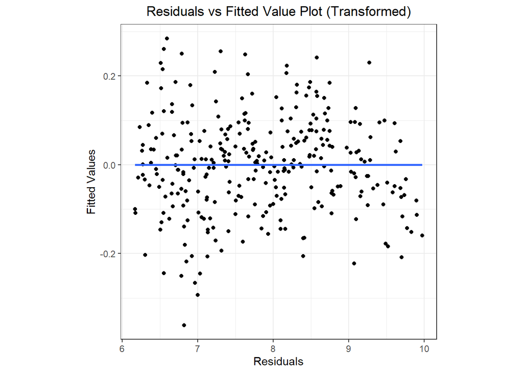

```r
# log transform plot
ggplot(data = diamonds.s.transform, mapping =
         aes(x = fitted.values, y = residuals)) +
  geom_point() +
  theme_bw() +
  theme(aspect.ratio = 1) +
  theme(plot.title = element_text(hjust = 0.5)) +
  xlab("Residuals") +
  ylab("Fitted Values") +
  ggtitle("Residuals vs Fitted Value Plot (Transformed)") +
  geom_smooth(method = 'lm', se = FALSE)
```

After viewing the difference in the two plots, we saw that the variance drastically improved, and we continued forward with our transformed model, assuming that the homoscedasity assumption to be met.

## Model Describes all Points (No Outliers)

#### DFFITS

```r
# diamonds.s.dffits <- data.frame("dffits" = dffits(diamonds.transform.lm))
# diamonds.s.dffits$obs <- 1:length(diamonds.s.transform$price)
#
# ggplot(data = diamonds.s.dffits) +
#   geom_point(mapping = aes(x = obs, y = abs(dffits))) +
#   geom_hline(mapping = aes(yintercept = 2 * sqrt(9 / length(obs))),
#              color = "red", linetype = "dashed") +
#   theme_bw() +
#   theme(aspect.ratio = 1)
#
# #diamonds.s.dffits[abs(diamonds.s.dffits$dffits) > 2 * sqrt(9 / 300), ]
```

## Fixing Multicollinearity (variable selection)

```r
# removing the residual and fitted values columns from the data frame to make
          # variable selection possible
diamonds.s.transform <- diamonds.s.transform[,-c(11,12)]

# the variable named "y" gave us some trouble with GLMNET, so we changed the name to           # "yvar".
names(diamonds.s.transform) <- c("price", "carat", "cut", "color", "clarity", "depth", "table", "x", "yvar", "z")

# model using clarity
clarity.model <- lm(price ~ carat + color + clarity, data = diamonds.s.transform)

# model using x
x.model <- lm(price ~ carat + color + x, data = diamonds.s.transform)

# model using y
y.model <- lm(price ~ carat + color + yvar, data = diamonds.s.transform)

# model using z
z.model <- lm(price ~ carat + color + z, data = diamonds.s.transform)
```

#### Clarity model

```r
summary(clarity.model)
```

```
##
## Call:
## lm(formula = price ~ carat + color + clarity, data = diamonds.s.transform)
##
## Residuals:
##      Min       1Q   Median       3Q      Max
## -0.88769 -0.21606  0.02794  0.21900  0.64227
##
## Coefficients:
##             Estimate Std. Error t value Pr(>|t|)
## (Intercept)  5.82554    0.16485  35.339  < 2e-16 ***
## carat        2.15327    0.04373  49.241  < 2e-16 ***
## colorE      -0.10947    0.06278  -1.744 0.082288 .
## colorF      -0.15886    0.06402  -2.481 0.013663 *
## colorG      -0.25995    0.06269  -4.147 4.46e-05 ***
## colorH      -0.30292    0.06646  -4.558 7.68e-06 ***
## colorI      -0.48620    0.07278  -6.681 1.24e-10 ***
## colorJ      -0.61933    0.11218  -5.521 7.60e-08 ***
## clarityIF    0.70190    0.17402   4.033 7.07e-05 ***
## claritySI1   0.38317    0.15551   2.464 0.014332 *
## claritySI2   0.32718    0.15706   2.083 0.038121 *
## clarityVS1   0.58812    0.15951   3.687 0.000272 ***
## clarityVS2   0.55659    0.15532   3.583 0.000399 ***
## clarityVVS1  0.77459    0.16942   4.572 7.21e-06 ***
## clarityVVS2  0.58915    0.16318   3.610 0.000361 ***
## ---
## Signif. codes:  0 '***' 0.001 '**' 0.01 '*' 0.05 '.' 0.1 ' ' 1
##
## Residual standard error: 0.2996 on 285 degrees of freedom
## Multiple R-squared:  0.9118, Adjusted R-squared:  0.9074
## F-statistic: 210.3 on 14 and 285 DF,  p-value: < 2.2e-16
```

#### X model

```r
#summary(x.model)
```

#### Y model

```r
#summary(y.model)
```

#### Z model

```r
#summary(z.model)
```

#### Clarity Model VIFs

```r
vif(clarity.model)
```

```
##             GVIF Df GVIF^(1/(2*Df))
## carat   1.421520  1        1.192275
## color   1.410925  6        1.029103
## clarity 1.446810  7        1.026734
```

```r
mean(vif(clarity.model)[,1])
```

```
## [1] 1.426418
```

#### Dealing with Outliers

To deal with the potential influential points we saw, we created a model with and without those outliers, then compared the two models to see if the points were, in fact, influential.

```r
# creating data frame without flagged DFFIT values
diamonds.without <- diamonds.s.transform[-diamonds.s.dffits[abs(diamonds.s.dffits$dffits) > 2 * sqrt(9 / 300), ]$obs, ]

# linear model of "without" data frame
without <- lm(price ~ carat + color + clarity, data = diamonds.without)

# # comparing both models
# clarity.model
# without

confint(clarity.model)
```

```
##                  2.5 %      97.5 %
## (Intercept)  5.5010701  6.15001540
## carat        2.0671924  2.23933870
## colorE      -0.2330361  0.01410093
## colorF      -0.2848689 -0.03284801
## colorG      -0.3833445 -0.13655647
## colorH      -0.4337453 -0.17209647
## colorI      -0.6294407 -0.34295106
## colorJ      -0.8401462 -0.39851740
## clarityIF    0.3593675  1.04444112
## claritySI1   0.0770757  0.68926138
## claritySI2   0.0180469  0.63631772
## clarityVS1   0.2741475  0.90208483
## clarityVS2   0.2508623  0.86231251
## clarityVVS1  0.4411197  1.10805681
## clarityVVS2  0.2679652  0.91034300
```

```r
confint(without)
```

```
##                   2.5 %      97.5 %
## (Intercept)  5.35253727  5.97654342
## carat        2.18297708  2.39791980
## colorE      -0.19918543  0.03759666
## colorF      -0.26019476 -0.01231531
## colorG      -0.37441905 -0.13367953
## colorH      -0.44615186 -0.18452407
## colorI      -0.62504611 -0.32389692
## colorJ      -1.34343603 -0.64018742
## clarityIF    0.43593363  1.08678232
## claritySI1   0.17820086  0.75084842
## claritySI2   0.07758881  0.65756737
## clarityVS1   0.35121757  0.94545778
## clarityVS2   0.32824604  0.90026488
## clarityVVS1  0.47731989  1.12988611
## clarityVVS2  0.36021930  0.96624735
```

The difference between the two models seemed pretty negligible, so we felt comfortable leaving in the outliers and continuing assuming that the model described all observations.

# Step 6: Checking Interaction Before Final Analysis

## Interaction Models

```r
# creating a model including interactions
clarity.model.int <- lm(price ~ carat + color + clarity + carat:color, data = diamonds.s.transform)

summary(clarity.model.int)
```

```
##
## Call:
## lm(formula = price ~ carat + color + clarity + carat:color, data = diamonds.s.transform)
##
## Residuals:
##      Min       1Q   Median       3Q      Max
## -0.93926 -0.18482  0.02157  0.21653  0.58589
##
## Coefficients:
##                Estimate Std. Error t value Pr(>|t|)
## (Intercept)   5.5073657  0.1867901  29.484  < 2e-16 ***
## carat         2.6133016  0.1626080  16.071  < 2e-16 ***
## colorE        0.0848772  0.1357154   0.625 0.532216
## colorF        0.0831458  0.1387289   0.599 0.549432
## colorG        0.0016880  0.1340444   0.013 0.989962
## colorH       -0.0292417  0.1490740  -0.196 0.844631
## colorI       -0.0007528  0.1511224  -0.005 0.996029
## colorJ        0.8310160  0.3737309   2.224 0.026978 *
## clarityIF     0.7330943  0.1688624   4.341 1.98e-05 ***
## claritySI1    0.4147173  0.1510045   2.746 0.006417 **
## claritySI2    0.3193634  0.1524312   2.095 0.037061 *
## clarityVS1    0.6254214  0.1548306   4.039 6.93e-05 ***
## clarityVS2    0.5879749  0.1507271   3.901 0.000120 ***
## clarityVVS1   0.8027829  0.1642539   4.887 1.73e-06 ***
## clarityVVS2   0.6331765  0.1586149   3.992 8.39e-05 ***
## carat:colorE -0.3093331  0.1909227  -1.620 0.106319
## carat:colorF -0.3935012  0.1860563  -2.115 0.035320 *
## carat:colorG -0.4228722  0.1797223  -2.353 0.019321 *
## carat:colorH -0.4390674  0.1869930  -2.348 0.019571 *
## carat:colorI -0.6454900  0.1819304  -3.548 0.000455 ***
## carat:colorJ -1.2765449  0.2925383  -4.364 1.80e-05 ***
## ---
## Signif. codes:  0 '***' 0.001 '**' 0.01 '*' 0.05 '.' 0.1 ' ' 1
##
## Residual standard error: 0.2893 on 279 degrees of freedom
## Multiple R-squared:  0.9194, Adjusted R-squared:  0.9136
## F-statistic: 159.2 on 20 and 279 DF,  p-value: < 2.2e-16
```

```r
# comparing the two models to see if there is a significant interaction
anova(clarity.model, clarity.model.int)
```

```
## Analysis of Variance Table
##
## Model 1: price ~ carat + color + clarity
## Model 2: price ~ carat + color + clarity + carat:color
##   Res.Df    RSS Df Sum of Sq     F    Pr(>F)
## 1    285 25.577
## 2    279 23.355  6    2.2215 4.423 0.0002722 ***
## ---
## Signif. codes:  0 '***' 0.001 '**' 0.01 '*' 0.05 '.' 0.1 ' ' 1
```

Looking at the output from the ANOVA test, we found a significant interaction between carat and color. We made note of this and continued using the clarity model including interaction terms. Generally here we would recheck assumptions but for the sake of this analysis we will forgo that and assume that all model assumptions are met.

# Step 7: Model Analysis and Predictions

After manipulating the data to meet linear regression assumptions, we now had a model that fit our data well and felt comfortable using this model to make inferences and predictions.

#### Predictions

While the prediction of diamond price my not be very useful for the average person, our findings may still be applicable in certain situations. Suppose a student hopes to predict how much he will need to save in order to buy his fiance a wedding ring that fits her requirements. Suppose that after careful consideration, this student’s fiance would like a .4 carat diamond with a “Very Good” cut, “H” color, and a clarity of “SI2”.

#### Prediction and Confidence Intervals

```r
new.data <- data.frame(carat = 0.4, cut = "Very Good", color = "H", clarity = "SI2")
#Prediction Interval
log.prediction <- predict(clarity.model.int, newdata = new.data, interval = "prediction")
(round(exp(log.prediction)[c(2, 1, 3)],  2))
```

```
## [1]  435.36  786.18 1419.68
```

We are 95% confident that a single diamond with the characteristics specified above (Carat:0.4, Cut:“Very Good”, Color:“H”, and Clarity:“SI2”) will cost between 435.36 and 1419.69 USD.

We feel comfortable in telling this student that he will spend anywhere between 435 and 1419 USD on the diamond for his fiance’s ring.

```r
new.data <- data.frame(carat = 0.4, cut = "Very Good", color = "H", clarity = "SI2")
#Confidence Interval
log.confidence <- predict(clarity.model.int, newdata = new.data, interval = "confidence")
round(exp(log.confidence)[c(2, 1, 3)], 2)
```

```
## [1] 671.39 786.18 920.58
```

We are 95% confident that diamonds with the characteristics specified above (Carat:0.4, Cut:“Very Good”, Color:“H”, and Clarity:“SI2”) will on average cost between 671.39 and 920.58 USD.

#### Confidence Intervals and R-Squared

```r
confint(clarity.model.int)
```

```
##                    2.5 %      97.5 %
## (Intercept)   5.13966871  5.87506261
## carat         2.29320720  2.93339598
## colorE       -0.18227892  0.35203328
## colorF       -0.18994248  0.35623414
## colorG       -0.26217890  0.26555490
## colorH       -0.32269430  0.26421090
## colorI       -0.29823773  0.29673215
## colorJ        0.09532565  1.56670639
## clarityIF     0.40068814  1.06550052
## claritySI1    0.11746440  0.71197012
## claritySI2    0.01930209  0.61942466
## clarityVS1    0.32063694  0.93020589
## clarityVS2    0.29126814  0.88468164
## clarityVVS1   0.47944847  1.12611724
## clarityVVS2   0.32094258  0.94541044
## carat:colorE -0.68516508  0.06649888
## carat:colorF -0.75975371 -0.02724877
## carat:colorG -0.77665618 -0.06908826
## carat:colorH -0.80716360 -0.07097116
## carat:colorI -1.00362063 -0.28735934
## carat:colorJ -1.85240754 -0.70068228
```

```r
exp(confint(clarity.model.int))
```

```
##                    2.5 %      97.5 %
## (Intercept)  170.6592207 356.0469531
## carat          9.9066595  18.7913372
## colorE         0.8333689   1.4219559
## colorF         0.8270067   1.4279419
## colorG         0.7693734   1.3041544
## colorH         0.7241952   1.3024028
## colorI         0.7421249   1.3454549
## colorJ         1.1000170   4.7908430
## clarityIF      1.4928516   2.9022913
## claritySI1     1.1246416   2.0380024
## claritySI2     1.0194896   1.8578588
## clarityVS1     1.3780052   2.5350311
## clarityVS2     1.3381233   2.4222131
## clarityVVS1    1.6151833   3.0836601
## clarityVVS2    1.3784264   2.5738696
## carat:colorE   0.5040070   1.0687598
## carat:colorF   0.4677816   0.9731191
## carat:colorG   0.4599414   0.9332443
## carat:colorH   0.4461217   0.9314888
## carat:colorI   0.3665499   0.7502421
## carat:colorJ   0.1568591   0.4962466
```

We concluded that there is a significant interaction between carat and color. This means that the effect that carat has on the price of the diamond changes as color changes in desirability. The effect that carat has on (log) price depends on the color of the diamond. For example, for diamonds with the same clarity, for every one unit increase in carat, the average (log) price will increase 2.62 for a diamond with color D, while increasing by only 2.30 for a color E diamond. Similarly we see an effect on (log) price as we continue change the color of the diamond. “For diamonds with the same clarity, for ever one unit increase in carat, the average (log) price will increase 2.62 for a diamond with color D, while increasing by only …”: “2.22 for a color F diamond.” “2.19 for a color G diamond.” “2.17 for a color H diamond.” “1.97 for a color I diamond.” “1.34 for a color J diamond.”

#### R-Squared

Looking at our R squared value, we found that our model fits the data very well. An $R^2$ of .91 indicates that approximately 91% of the variation in the price of a diamond can be explained by our model.

# Summary and Conclusions